# SingleSpeciesVignette

P Galante

2020-07-31

## Single species range change metrics

Translating a species’ current distribution into meaningful conservation metrics in a repeatable and transparent way to inform conservation planning and decision-making remains an outstanding issue in conservation biology. By using a species distribution model (SDM), as well as landscape requirements (e.g., forest cover), we can mask the output of an SDM to only those areas likely to be suitable to estimate the species’ current range (e.g., in maskRangeR). From these reduced model outputs, IUCN metrics regarding area of occupancy (upper bounds of AOO) and extent of occurrence (EOO) can be calculated to inform the assessment of a species’ conservation status. In addition, we can calculate the proportion of a species’ range size that is protected, that is threatened, or that is associated with different land cover types. If past or future model projections or geospatial data on habitat for masking are available, we can also calculate and visualize change in these metrics over time. These change metrics can then inform IUCN red-listing and forward-thinking conservation planning. Beyond single species, we can combine models from multiple species to calculate community-level metrics of conservation interest such as richness, spatial and temporal turnover, endemism, and phylogenetic diversity, to understand complementarity across space and to further aid planning and decision-making.

```r
library(changeRangeR)
library(raster)
library(rgeos)
library(rgdal)
library(sf)
library(dplyr)
```

# Range size

Calculating range size is as simple as multiplying the number of cells in a binary raster by the resolution (in km) squared. This method is especially useful when your raster is projected. For unprojected rasters, see ?raster::area

```r
p <-raster("inst/extdata/DemoData/SDM/olinguito/Forest_suitable_projected1.tif")
# Check that your raster is projected in meters
crs(p)
```

```
## CRS arguments:
##  +proj=utm +zone=18 +south +datum=WGS84 +units=m +no_defs
```

```r
# find the number of cells that are not NA
pCells <- ncell(p[!is.na(p)])
# Convert the raster resolution to km^s
Resolution <- (res(p)/1000)^2
# Multiply the two
area <- pCells * Resolution

paste0("area = ", area[1], " km^2")
```

```
## [1] "area = 56965.3594012526 km^2"
```

# EOO

## EOO Occurrences

Calculate the extent of occupancy around occurrence localities

```r
locs <- read.csv("inst/extdata/DemoData/locs/10KM_thin_2017.csv")
# Look at the first 5 rows. Not that there are three columns: Species, Longitude, Latitude
head(locs)
```

```
##               species     long     lat
## 1 Bassaricyon neblina -76.5815  3.5009
## 2 Bassaricyon neblina -75.4988  6.2083
## 3 Bassaricyon neblina -78.7491 -0.4550
## 4 Bassaricyon neblina -76.1152  6.3753
## 5 Bassaricyon neblina -76.4453  1.9270
## 6 Bassaricyon neblina -76.8830  2.5330
```

```r
# Create a minimum convex polygon around the occurrences
eoo <- mcp(locs[,2:3])
```

```
## WARNING: this minimum convex polygon has no coordinate reference system.
```

```r
# Define the coordinate reference system as unprojected
crs(eoo) <- "+proj=longlat +ellps=WGS84 +datum=WGS84 +no_defs"
area <- area(eoo)/1000000
## area is measured in meters^2
paste0(area, " km ^2")
```

```
## [1] "91721.7270949235 km ^2"
```

## EOO SDM

Calculate the extent of occupancy from a thresholded SDM

```r
p <-raster("inst/extdata/DemoData/SDM/olinguito/Climatically_suitable_projected1.tif")
# Threshold of the minimum training presence
thr <- min(values(p), na.rm=T)
p[p<thr] <- NA
p.pts <- rasterToPoints(p)
eooSDM <- mcp(p.pts[,1:2])
```

```
## WARNING: this minimum convex polygon has no coordinate reference system.
```

```r
aeoosdm <- area(eooSDM)/1000000
paste0(aeoosdm, " meters ^2")
```

```
## [1] "306279.933959894 meters ^2"
```

# AOO

Calculating the areas of occupancy measured in gridcells where the resolution is 2km

## AOO occurrence points

Calculate the area of occupancy that contains occurrence records

```r
p <- raster("inst/extdata/DemoData/SDM/olinguito/Climatically_suitable_projected1.tif")
# Using unfiltered records
locs <- read.csv("inst/extdata/DemoData/locs/All_localities_30n.csv")
locs <- locs[,1:2]
p[!is.na(p)] <- 1
AOOlocs<-aooArea(r = p,proj = crs(p), locs = locs)

print(AOOlocs)
```

```
## [1] "AOO of cells with occurrence records:120km^2"
```

## AOO pre-masked SDM

```r
p <-raster("inst/extdata/DemoData/SDM/olinguito/Climatically_suitable_projected1.tif")
# Convert to binary
p[!is.na(p)] <- 1
AOO<-aooArea(r = p,proj = crs(p))
print(AOO)
```

```
## [1] "AOO: 130052 km^2"
```

## AOO masked SDM

```r
p <-raster("inst/extdata/DemoData/SDM/olinguito/Forest_suitable_projected1.tif")
# Convert to binary
p[!is.na(p)] <- 1
AOO<-aooArea(r = p,proj = crs(p))
print(AOO)
```

```
## [1] "AOO: 103576 km^2"
```

# Optimized Model Threshold

Determining the best threshold and area for the SDM. For each increment of 0.01 between a user-specified threshold and the maximum SDM prediction value, the prediction is thresholded to this value to make a binary raster. This raster is then converted to points, which are used to delineate a trial MCP. Each trial MCP is spatially intersected with the original MCP (based on the occurrence coordinates) and the original occurrence points. The Jaccard similarity index is calculated to determine geographic similarity between the trial and observed MCP. The trial MCP is also spatially intersected with the original occurrence points to determine how many were omitted. The “best” MCP is the one that has the highest JSI and also omits the least original occurrence points.

```r
p <- raster("inst/extdata/DemoData/SDM/olinguito/olinguitoSDM.tif")
xy <- read.csv("inst/extdata/DemoData/locs/10KM_thin_2017.csv")
ch.orig <- mcp(xy[,2:3])
```

```
## WARNING: this minimum convex polygon has no coordinate reference system.
```

```r
thr <- 0.3380209
SDMeoo <- mcpSDM(p = p, xy = xy[,2:3], ch.orig = ch.orig, thr = thr)
# Check the output
SDMeoo
```

```
## $jsi
##  [1] 0.05001384 0.05001759 0.05004639 0.05011180 0.05068842 0.05070592
##  [7] 0.05108942 0.05114548 0.05408432 0.05646642 0.05692540 0.05699842
## [13] 0.05703103 0.05706109 0.05712634 0.05822613 0.05859980 0.05861419
## [19] 0.05908503 0.05938596 0.05949351 0.05964649 0.05976235 0.05981566
## [25] 0.06029873 0.06067109 0.06077718 0.06097874 0.06106401 0.06126506
## [31] 0.06141915 0.06155827 0.06164195 0.06176097 0.06188650 0.06209165
## [37] 0.06280664 0.06288058 0.06295917 0.06319632 0.06368854 0.06761048
## [43] 0.06783378 0.06806077 0.06815294 0.06852636 0.06866409 0.06894252
## [49] 0.06951222 0.07004717 0.07033226 0.07079381 0.07190832 0.09096866
## [55] 0.09127588 0.09244362 0.03447275 0.03468914 0.03626676 0.03667725
## [61] 0.03790107 0.00000000 0.00000000 0.00000000
##
## $thr
##  [1] 0.3380209 0.3480209 0.3580209 0.3680209 0.3780209 0.3880209 0.3980209
##  [8] 0.4080209 0.4180209 0.4280209 0.4380209 0.4480209 0.4580209 0.4680209
## [15] 0.4780209 0.4880209 0.4980209 0.5080209 0.5180209 0.5280209 0.5380209
## [22] 0.5480209 0.5580209 0.5680209 0.5780209 0.5880209 0.5980209 0.6080209
## [29] 0.6180209 0.6280209 0.6380209 0.6480209 0.6580209 0.6680209 0.6780209
## [36] 0.6880209 0.6980209 0.7080209 0.7180209 0.7280209 0.7380209 0.7480209
## [43] 0.7580209 0.7680209 0.7780209 0.7880209 0.7980209 0.8080209 0.8180209
## [50] 0.8280209 0.8380209 0.8480209 0.8580209 0.8680209 0.8780209 0.8880209
## [57] 0.8980209 0.9080209 0.9180209 0.9280209 0.9380209 0.9480209 0.9580209
## [64] 0.9680209
##
## $ov.pts
##  [1] 18 18 18 18 18 18 18 18 18 18 18 18 18 18 18 18 18 18 18 18 18 18 18 18 18
## [26] 18 18 18 18 18 18 18 18 18 18 18 18 18 18 18 18 18 18 18 18 18 18 18 18 18
## [51] 18 18 18 14 14 14  7  7  7  7  7  0  0  0
##
## $best.fit
## class       : SpatialPolygons
## features    : 1
## extent      : -83.89583, -72.0375, -4.6375, 11.17083  (xmin, xmax, ymin, ymax)
## crs         : +proj=longlat +datum=WGS84 +no_defs
##
## $best.fit.ind
## [1] 53
```

# Ratio overlap

## Current

```r
r <-raster("inst/extdata/DemoData/SDM/olinguito/Forest_suitable_projected1.tif")
shp <- readOGR("inst/extdata/DemoData/shapefiles", "WDPA_COL_olinguito")
# View the fields
colnames(shp@data)
```

```
## [1] "NAME"       "ORIG_NAME"  "DESIG"      "DESIG_ENG"  "DESIG_TYPE"
```

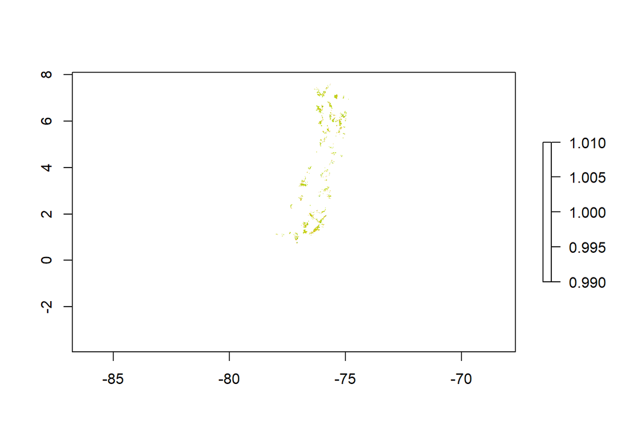

```r
# Pick the field you are interested in
field <- "DESIG_ENG"
category <- "All"
ratio.Overlap <- ratioOverlap(r = r, shp = shp, field = field, category = category)
# Look at the range that is protected
plot(ratio.Overlap$maskedRange)
```

```r
# The proportion of the range that is protected
ratio.Overlap$ratio
```

```
## [1] "Percentage of range within shape is 11.41078182275%"
```

## Future

```r
# create list of shapefiles
shp1 <- readOGR("inst/extdata/DemoData/shapefiles", "WDPA_COL_olinguito")
```

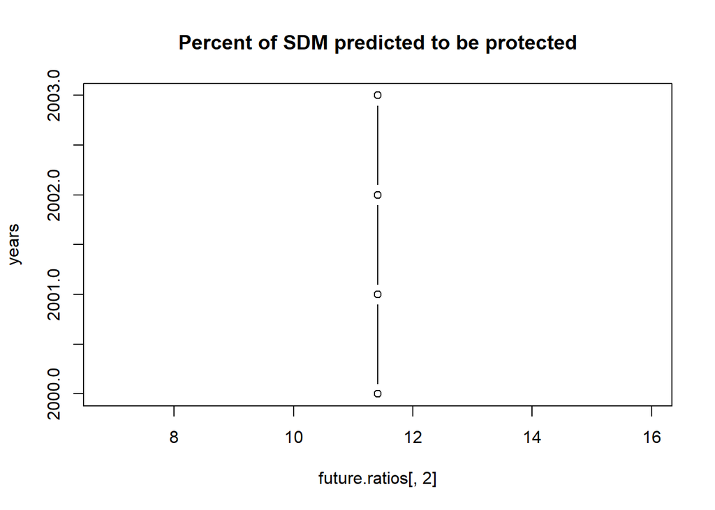

```r
shp2 <- shp1
shp3 <- shp1
shp4 <- shp1
futures <- list(shp1,shp2, shp3, shp4)
# load raster
r <-raster("inst/extdata/DemoData/SDM/olinguito/Forest_suitable_projected1.tif")
r <- list(r,r,r,r)
field <- "DESIG_ENG"
category <- "All"
# supply names for r and futures
r.names <- c("r1", "r2", "r3", "r4")
futures.names <- c("f1", "f2", "f3", "f4")
# Calculate the overlap for each time period
future.ratios <- futureOverlap(r = r, futures = futures, field = field, category = category, futures.names, r.names)
## Plot
# Create list of years from which landcover comes
years <- c(2000, 2001, 2002, 2003)
# Plot
plot(x = future.ratios[,2], y = years, type = "b", main = "Percent of SDM predicted to be protected")
```